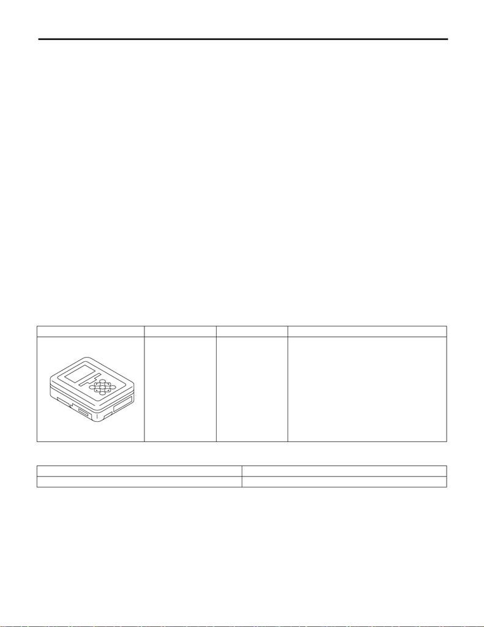

BC(diag)-4

General Description

BODY CONTROL SYSTEM (DIAGNOSTICS)

3. General Description

A: CAUTION

1. SRS AIRBAG SYSTEM

Airbag system wiring harness is routed near the body integrated unit and body control circuits.

CAUTION:

• Do not use the electrical test equipment on all airbag system wiring harnesses and connectors.

B: INSPECTION

Before performing diagnosis, check the following items which might affect body control system problems.

1) Measure the battery voltage and check electrolyte.

Standard voltage: 12 V or more

Specific gravity: 1.260 or more

2) Check the fuse condition.

Make sure that ampere of the fuse is setting value, and it is not blown out.

3) Check the connecting condition of harness and harness connector.

4) Confirm settings of body integrated unit are corresponded to vehicle equipment. <Ref. to BC(diag)-22,

OPERATION, Registration Body Integrated Unit.>

5) Make sure that the User Customizing of the body integrated unit matches the vehicle equipment. <Ref. to

BC(diag)-20, OPERATION, User Customizing.>

6) Confirm “Factory initial setting” of body integrated unit registrations is “Market”.

C: PREPARATION TOOL

1. SPECIAL TOOL

2. GENERAL TOOL

ILLUSTRATION TOOL NUMBER DESCRIPTION REMARKS

1B022XU0 SUBARU SELECT

MONITOR III KIT

Used for troubleshooting the electrical system.

TOOL NAME REMARKS

Circuit tester Used for measuring resistance, voltage and current.